# Optimal Treatment Analysis

## Methods Detail

We’re interested in the causal parameters $E[Y_a]$ for all values of $a \in \mathcal{A}$. These parameters represent the mean outcome if, possibly contrary to fact, we intervened to set all units to have $A=a$. Under the randomization and positivity assumptions, these are identified by the statistical parameters $\psi_a=E_W[E_{Y|A,W}(Y|A=a,W)]$. In addition, we’re interested in the mean of $Y$, $E[Y]$ under no intervention (the observed mean). We will estimate these parameters by using SuperLearner to fit the relevant likelihood factors – $E_{Y|A,W}(Y|A=a,W)$ and $p(A=a|W)$, and then updating our likelihood fit using a joint TMLE.

For unadjusted analyses ($W=\{\}$), initial likelihoods were estimated using Lrnr_glm to estimate the simple $E(Y|A)$ and Lrnr_mean to estimate $p(A)$. For adjusted analyses, a small library containing Lrnr_glmnet, Lrnr_xgboost, and Lrnr_mean was used.

Having estimated these parameters, we will then use the delta method to estimate relative risks and attributable risks relative to a prespecified baseline level of $A$.

[output not shown]

# Results Detail

## Results Plots

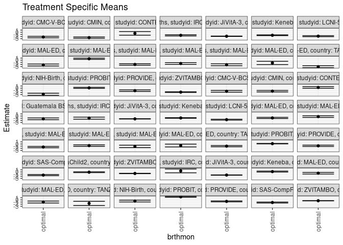

## Results Table

### Parameter: TSM

| agecat | studyid | country | intervention_level | baseline_level | estimate | ci_lower | ci_upper |
| --- | --- | --- | --- | --- | --- | --- | --- |
| Birth | IRC | INDIA | optimal | observed | 0.4832085 | -0.4114724 | 1.3778895 |
| Birth | JiVitA-3 | BANGLADESH | optimal | observed | -1.4575210 | -1.5160733 | -1.3989687 |
| Birth | Keneba | GAMBIA | optimal | observed | 0.1584165 | -0.0701687 | 0.3870017 |
| Birth | MAL-ED | BANGLADESH | optimal | observed | -0.5913041 | -0.9867537 | -0.1958544 |
| Birth | MAL-ED | PERU | optimal | observed | -1.0032956 | -1.4566957 | -0.5498956 |
| Birth | MAL-ED | TANZANIA, UNITED REPUBLIC OF | optimal | observed | -1.6532497 | -2.6378175 | -0.6686819 |
| Birth | NIH-Birth | BANGLADESH | optimal | observed | -0.5544193 | -0.9636177 | -0.1452209 |
| Birth | PROBIT | BELARUS | optimal | observed | 1.4360412 | 1.2425926 | 1.6294898 |
| Birth | PROVIDE | BANGLADESH | optimal | observed | -0.7104578 | -0.9243611 | -0.4965545 |
| Birth | SAS-CompFeed | INDIA | optimal | observed | -1.2344355 | -1.4632692 | -1.0056017 |
| Birth | ZVITAMBO | ZIMBABWE | optimal | observed | -0.4076701 | -0.4699014 | -0.3454388 |
| 6 months | CMC-V-BCS-2002 | INDIA | optimal | observed | -1.4722394 | -1.8890918 | -1.0553871 |
| 6 months | CMIN | BANGLADESH | optimal | observed | -1.4252622 | -1.7905970 | -1.0599273 |
| 6 months | CONTENT | PERU | optimal | observed | 0.3104789 | -0.0716031 | 0.6925609 |
| 6 months | Guatemala BSC | GUATEMALA | optimal | observed | -1.2846397 | -1.7018942 | -0.8673852 |
| 6 months | IRC | INDIA | optimal | observed | -0.9917191 | -1.4744330 | -0.5090052 |
| 6 months | JiVitA-3 | BANGLADESH | optimal | observed | -1.3180440 | -1.3864998 | -1.2495882 |
| 6 months | Keneba | GAMBIA | optimal | observed | -0.8988343 | -1.0526517 | -0.7450169 |
| 6 months | LCNI-5 | MALAWI | optimal | observed | -1.6933692 | -1.9068650 | -1.4798733 |
| 6 months | MAL-ED | BANGLADESH | optimal | observed | -0.8832230 | -1.1803519 | -0.5860942 |
| 6 months | MAL-ED | BRAZIL | optimal | observed | -0.2533543 | -0.6541348 | 0.1474262 |
| 6 months | MAL-ED | INDIA | optimal | observed | -1.4266286 | -1.7608366 | -1.0924205 |
| 6 months | MAL-ED | NEPAL | optimal | observed | -0.7527324 | -1.1024966 | -0.4029682 |
| 6 months | MAL-ED | PERU | optimal | observed | -1.1357250 | -1.7099756 | -0.5614745 |
| 6 months | MAL-ED | SOUTH AFRICA | optimal | observed | -0.7280787 | -1.3884260 | -0.0677315 |
| 6 months | MAL-ED | TANZANIA, UNITED REPUBLIC OF | optimal | observed | -1.0074614 | -1.3038903 | -0.7110324 |
| 6 months | PROBIT | BELARUS | optimal | observed | 0.1717870 | 0.0598182 | 0.2837558 |
| 6 months | PROVIDE | BANGLADESH | optimal | observed | -0.8517488 | -1.1633742 | -0.5401234 |
| 6 months | SAS-CompFeed | INDIA | optimal | observed | -1.4873745 | -1.7603492 | -1.2143998 |
| 6 months | TanzaniaChild2 | TANZANIA, UNITED REPUBLIC OF | optimal | observed | -0.1240974 | -0.3240988 | 0.0759040 |
| 6 months | ZVITAMBO | ZIMBABWE | optimal | observed | -0.7148057 | -0.8011202 | -0.6284912 |
| 24 months | CMC-V-BCS-2002 | INDIA | optimal | observed | -2.2536784 | -2.5975205 | -1.9098363 |
| 24 months | CMIN | BANGLADESH | optimal | observed | -2.5261952 | -2.8350270 | -2.2173635 |
| 24 months | CONTENT | PERU | optimal | observed | -0.5313121 | -1.3858683 | 0.3232442 |
| 24 months | IRC | INDIA | optimal | observed | -1.4459185 | -1.7302791 | -1.1615579 |
| 24 months | JiVitA-3 | BANGLADESH | optimal | observed | -1.8680562 | -1.9542580 | -1.7818544 |
| 24 months | Keneba | GAMBIA | optimal | observed | -1.4108518 | -1.5809335 | -1.2407700 |
| 24 months | LCNI-5 | MALAWI | optimal | observed | -1.8317231 | -2.0708207 | -1.5926255 |
| 24 months | MAL-ED | BANGLADESH | optimal | observed | -2.2691041 | -2.7365449 | -1.8016633 |
| 24 months | MAL-ED | BRAZIL | optimal | observed | 0.6713097 | 0.3816029 | 0.9610165 |
| 24 months | MAL-ED | INDIA | optimal | observed | -2.0077113 | -2.3645025 | -1.6509201 |
| 24 months | MAL-ED | NEPAL | optimal | observed | -1.5603020 | -1.9926366 | -1.1279675 |
| 24 months | MAL-ED | PERU | optimal | observed | -2.1325654 | -2.5803733 | -1.6847575 |
| 24 months | MAL-ED | SOUTH AFRICA | optimal | observed | -1.2930986 | -2.0628631 | -0.5233342 |
| 24 months | MAL-ED | TANZANIA, UNITED REPUBLIC OF | optimal | observed | -3.0661321 | -3.5428189 | -2.5894453 |
| 24 months | NIH-Birth | BANGLADESH | optimal | observed | -2.8762736 | -3.3668765 | -2.3856708 |
| 24 months | PROBIT | BELARUS | optimal | observed | 0.1145770 | -0.1355445 | 0.3646985 |
| 24 months | PROVIDE | BANGLADESH | optimal | observed | -1.1921433 | -1.5678820 | -0.8164047 |
| 24 months | ZVITAMBO | ZIMBABWE | optimal | observed | -1.8848427 | -2.0769541 | -1.6927313 |

### Parameter: E(Y)

| agecat | studyid | country | intervention_level | baseline_level | estimate | ci_lower | ci_upper |
| --- | --- | --- | --- | --- | --- | --- | --- |
| Birth | IRC | INDIA | observed | observed | -0.3080412 | -0.4687931 | -0.1472894 |
| Birth | JiVitA-3 | BANGLADESH | observed | observed | -1.5894148 | -1.6086362 | -1.5701935 |
| Birth | Keneba | GAMBIA | observed | observed | 0.0308036 | -0.0328378 | 0.0944451 |
| Birth | MAL-ED | BANGLADESH | observed | observed | -1.1180952 | -1.2525408 | -0.9836496 |
| Birth | MAL-ED | PERU | observed | observed | -0.8827897 | -1.0001058 | -0.7654736 |
| Birth | MAL-ED | TANZANIA, UNITED REPUBLIC OF | observed | observed | -1.1556000 | -1.3655361 | -0.9456639 |
| Birth | NIH-Birth | BANGLADESH | observed | observed | -0.9310197 | -1.0197391 | -0.8423003 |
| Birth | PROBIT | BELARUS | observed | observed | 1.3114417 | 1.1524752 | 1.4704082 |
| Birth | PROVIDE | BANGLADESH | observed | observed | -0.8851020 | -0.9601332 | -0.8100709 |
| Birth | SAS-CompFeed | INDIA | observed | observed | -1.4314217 | -1.5099245 | -1.3529189 |
| Birth | ZVITAMBO | ZIMBABWE | observed | observed | -0.5002724 | -0.5208163 | -0.4797285 |
| 6 months | CMC-V-BCS-2002 | INDIA | observed | observed | -1.4234508 | -1.5645974 | -1.2823042 |
| 6 months | CMIN | BANGLADESH | observed | observed | -1.7844376 | -1.9222926 | -1.6465825 |
| 6 months | CONTENT | PERU | observed | observed | -0.2785256 | -0.4098735 | -0.1471776 |
| 6 months | Guatemala BSC | GUATEMALA | observed | observed | -1.5619008 | -1.6727702 | -1.4510313 |
| 6 months | IRC | INDIA | observed | observed | -1.2344062 | -1.3658524 | -1.1029600 |
| 6 months | JiVitA-3 | BANGLADESH | observed | observed | -1.3130932 | -1.3362359 | -1.2899505 |
| 6 months | Keneba | GAMBIA | observed | observed | -0.9041369 | -0.9513363 | -0.8569376 |
| 6 months | LCNI-5 | MALAWI | observed | observed | -1.6601907 | -1.7297701 | -1.5906113 |
| 6 months | MAL-ED | BANGLADESH | observed | observed | -1.2049931 | -1.3222136 | -1.0877726 |
| 6 months | MAL-ED | BRAZIL | observed | observed | 0.0475758 | -0.0963508 | 0.1915023 |
| 6 months | MAL-ED | INDIA | observed | observed | -1.2115254 | -1.3298727 | -1.0931782 |
| 6 months | MAL-ED | NEPAL | observed | observed | -0.5615819 | -0.6741832 | -0.4489807 |
| 6 months | MAL-ED | PERU | observed | observed | -1.3236661 | -1.4316775 | -1.2156546 |
| 6 months | MAL-ED | SOUTH AFRICA | observed | observed | -1.0633202 | -1.1909180 | -0.9357224 |
| 6 months | MAL-ED | TANZANIA, UNITED REPUBLIC OF | observed | observed | -1.3687449 | -1.4907629 | -1.2467270 |
| 6 months | PROBIT | BELARUS | observed | observed | 0.0980074 | 0.0062724 | 0.1897424 |
| 6 months | PROVIDE | BANGLADESH | observed | observed | -1.0916915 | -1.1661176 | -1.0172654 |
| 6 months | SAS-CompFeed | INDIA | observed | observed | -1.4018563 | -1.4810585 | -1.3226541 |
| 6 months | TanzaniaChild2 | TANZANIA, UNITED REPUBLIC OF | observed | observed | -0.5434389 | -0.5924056 | -0.4944722 |
| 6 months | ZVITAMBO | ZIMBABWE | observed | observed | -0.8679450 | -0.8935071 | -0.8423828 |
| 24 months | CMC-V-BCS-2002 | INDIA | observed | observed | -2.5588679 | -2.6583730 | -2.4593629 |
| 24 months | CMIN | BANGLADESH | observed | observed | -2.5109504 | -2.6361514 | -2.3857494 |
| 24 months | CONTENT | PERU | observed | observed | -0.6868598 | -0.8388476 | -0.5348719 |
| 24 months | IRC | INDIA | observed | observed | -1.7987775 | -1.8923914 | -1.7051636 |
| 24 months | JiVitA-3 | BANGLADESH | observed | observed | -2.0136481 | -2.0413552 | -1.9859409 |
| 24 months | Keneba | GAMBIA | observed | observed | -1.5774356 | -1.6272400 | -1.5276311 |
| 24 months | LCNI-5 | MALAWI | observed | observed | -1.8861485 | -1.9671802 | -1.8051169 |
| 24 months | MAL-ED | BANGLADESH | observed | observed | -1.9783962 | -2.1050210 | -1.8517715 |
| 24 months | MAL-ED | BRAZIL | observed | observed | 0.0061144 | -0.1625850 | 0.1748138 |
| 24 months | MAL-ED | INDIA | observed | observed | -1.8861894 | -2.0110006 | -1.7613783 |
| 24 months | MAL-ED | NEPAL | observed | observed | -1.3075877 | -1.4270718 | -1.1881037 |
| 24 months | MAL-ED | PERU | observed | observed | -1.7524710 | -1.8736426 | -1.6312994 |
| 24 months | MAL-ED | SOUTH AFRICA | observed | observed | -1.6450595 | -1.7797240 | -1.5103950 |
| 24 months | MAL-ED | TANZANIA, UNITED REPUBLIC OF | observed | observed | -2.6455607 | -2.7807256 | -2.5103959 |
| 24 months | NIH-Birth | BANGLADESH | observed | observed | -2.2190579 | -2.3217459 | -2.1163699 |
| 24 months | PROBIT | BELARUS | observed | observed | -0.1442891 | -0.4253755 | 0.1367972 |
| 24 months | PROVIDE | BANGLADESH | observed | observed | -1.6024221 | -1.6857420 | -1.5191023 |
| 24 months | ZVITAMBO | ZIMBABWE | observed | observed | -1.6055701 | -1.6625562 | -1.5485840 |

### Parameter: PAR

| agecat | studyid | country | intervention_level | baseline_level | estimate | ci_lower | ci_upper |
| --- | --- | --- | --- | --- | --- | --- | --- |
| Birth | IRC | INDIA | optimal | observed | -0.7912498 | -1.6530008 | 0.0705013 |
| Birth | JiVitA-3 | BANGLADESH | optimal | observed | -0.1318938 | -0.1876845 | -0.0761031 |
| Birth | Keneba | GAMBIA | optimal | observed | -0.1276129 | -0.3444376 | 0.0892118 |
| Birth | MAL-ED | BANGLADESH | optimal | observed | -0.5267912 | -0.9145921 | -0.1389903 |
| Birth | MAL-ED | PERU | optimal | observed | 0.1205059 | -0.3196240 | 0.5606359 |
| Birth | MAL-ED | TANZANIA, UNITED REPUBLIC OF | optimal | observed | 0.4976497 | -0.4323166 | 1.4276160 |
| Birth | NIH-Birth | BANGLADESH | optimal | observed | -0.3766004 | -0.7647986 | 0.0115978 |
| Birth | PROBIT | BELARUS | optimal | observed | -0.1245995 | -0.2239506 | -0.0252483 |
| Birth | PROVIDE | BANGLADESH | optimal | observed | -0.1746442 | -0.3805095 | 0.0312210 |
| Birth | SAS-CompFeed | INDIA | optimal | observed | -0.1969863 | -0.3884993 | -0.0054732 |
| Birth | ZVITAMBO | ZIMBABWE | optimal | observed | -0.0926023 | -0.1525010 | -0.0327036 |
| 6 months | CMC-V-BCS-2002 | INDIA | optimal | observed | 0.0487887 | -0.3483557 | 0.4459330 |
| 6 months | CMIN | BANGLADESH | optimal | observed | -0.3591754 | -0.7259622 | 0.0076114 |
| 6 months | CONTENT | PERU | optimal | observed | -0.5890045 | -0.9774767 | -0.2005323 |
| 6 months | Guatemala BSC | GUATEMALA | optimal | observed | -0.2772611 | -0.6775867 | 0.1230645 |
| 6 months | IRC | INDIA | optimal | observed | -0.2426872 | -0.7059144 | 0.2205401 |
| 6 months | JiVitA-3 | BANGLADESH | optimal | observed | 0.0049508 | -0.0595595 | 0.0694611 |
| 6 months | Keneba | GAMBIA | optimal | observed | -0.0053027 | -0.1522423 | 0.1416370 |
| 6 months | LCNI-5 | MALAWI | optimal | observed | 0.0331785 | -0.1683461 | 0.2347030 |
| 6 months | MAL-ED | BANGLADESH | optimal | observed | -0.3217701 | -0.6162734 | -0.0272667 |
| 6 months | MAL-ED | BRAZIL | optimal | observed | 0.3009300 | -0.1053304 | 0.7071905 |
| 6 months | MAL-ED | INDIA | optimal | observed | 0.2151031 | -0.1145602 | 0.5447665 |
| 6 months | MAL-ED | NEPAL | optimal | observed | 0.1911505 | -0.1463559 | 0.5286569 |
| 6 months | MAL-ED | PERU | optimal | observed | -0.1879410 | -0.7346781 | 0.3587961 |
| 6 months | MAL-ED | SOUTH AFRICA | optimal | observed | -0.3352415 | -0.9747763 | 0.3042934 |
| 6 months | MAL-ED | TANZANIA, UNITED REPUBLIC OF | optimal | observed | -0.3612836 | -0.6617867 | -0.0607804 |
| 6 months | PROBIT | BELARUS | optimal | observed | -0.0737796 | -0.1613082 | 0.0137490 |
| 6 months | PROVIDE | BANGLADESH | optimal | observed | -0.2399427 | -0.5389064 | 0.0590210 |
| 6 months | SAS-CompFeed | INDIA | optimal | observed | 0.0855182 | -0.1963117 | 0.3673480 |
| 6 months | TanzaniaChild2 | TANZANIA, UNITED REPUBLIC OF | optimal | observed | -0.4193415 | -0.6105421 | -0.2281409 |
| 6 months | ZVITAMBO | ZIMBABWE | optimal | observed | -0.1531393 | -0.2348934 | -0.0713852 |
| 24 months | CMC-V-BCS-2002 | INDIA | optimal | observed | -0.3051895 | -0.6456029 | 0.0352238 |
| 24 months | CMIN | BANGLADESH | optimal | observed | 0.0152448 | -0.2998095 | 0.3302991 |
| 24 months | CONTENT | PERU | optimal | observed | -0.1555477 | -0.9837441 | 0.6726487 |
| 24 months | IRC | INDIA | optimal | observed | -0.3528590 | -0.6281580 | -0.0775601 |
| 24 months | JiVitA-3 | BANGLADESH | optimal | observed | -0.1455919 | -0.2271920 | -0.0639918 |
| 24 months | Keneba | GAMBIA | optimal | observed | -0.1665838 | -0.3283794 | -0.0047882 |
| 24 months | LCNI-5 | MALAWI | optimal | observed | -0.0544254 | -0.2894895 | 0.1806387 |
| 24 months | MAL-ED | BANGLADESH | optimal | observed | 0.2907079 | -0.1496341 | 0.7310498 |
| 24 months | MAL-ED | BRAZIL | optimal | observed | -0.6651953 | -0.9865933 | -0.3437974 |
| 24 months | MAL-ED | INDIA | optimal | observed | 0.1215219 | -0.2287523 | 0.4717960 |
| 24 months | MAL-ED | NEPAL | optimal | observed | 0.2527143 | -0.1652362 | 0.6706648 |
| 24 months | MAL-ED | PERU | optimal | observed | 0.3800944 | -0.0574332 | 0.8176221 |
| 24 months | MAL-ED | SOUTH AFRICA | optimal | observed | -0.3519609 | -1.1065468 | 0.4026250 |
| 24 months | MAL-ED | TANZANIA, UNITED REPUBLIC OF | optimal | observed | 0.4205713 | -0.0442042 | 0.8853469 |
| 24 months | NIH-Birth | BANGLADESH | optimal | observed | 0.6572158 | 0.1917204 | 1.1227111 |
| 24 months | PROBIT | BELARUS | optimal | observed | -0.2588662 | -0.5771387 | 0.0594064 |
| 24 months | PROVIDE | BANGLADESH | optimal | observed | -0.4102788 | -0.7698367 | -0.0507209 |
| 24 months | ZVITAMBO | ZIMBABWE | optimal | observed | 0.2792726 | 0.0880957 | 0.4704495 |